# BRFSS Data Analysis

## Introduction

So far, we have learned followings:

1. Study Design
2. Quantifying Extent of Disease
3. Summarizing Data collected in the sample
4. The Role of Probability

Probably, it is a good time to have a look **a real world data**, [BRFSS data](https://www.cdc.gov/brfss/), set and how these knowledges are applied.

## BRFSS Data

2018 BRFSS data can be downloadable from [Here](https://www.cdc.gov/brfss/annual_data/annual_2018.html).

Go to the link for more detailed information. For a simple download, click here. [Download](https://www.cdc.gov/brfss/annual_data/2018/files/LLCP2018XPT.zip)

Codebook, downloadable here. [Download](https://www.cdc.gov/brfss/annual_data/2018/pdf/codebook18_llcp-v2-508.pdf)

Unzip it, and put `LLCP2018.XPT` in data directory.

```r
pacman::p_load(RCurl, foreign, downloader, survey, srvyr, ggplot2, dplyr, tidyverse)
```

```r
brfss18 <- read.xport('data/LLCP2018.XPT')
```

```r
sprintf("BRFSS data have %d recores, and %d number of variables", nrow(brfss18), ncol(brfss18))
```

'BRFSS data have 437436 recores, and 275 number of variables'

```r
brfss18[1:5,]
```

| X_STATE | FMONTH | IDATE | IMONTH | IDAY | IYEAR | DISPCODE | SEQNO | X_PSU | CTELENM1 | ... | X_MAM5022 | X_RFPAP34 | X_RFPSA22 | X_RFBLDS3 | X_COL10YR | X_HFOB3YR | X_FS5YR | X_FOBTFS | X_CRCREC | X_AIDTST3 |
| --- | --- | --- | --- | --- | --- | --- | --- | --- | --- | --- | --- | --- | --- | --- | --- | --- | --- | --- | --- | --- |
| 1 | 1 | 01052018 | 01 | 05 | 2018 | 1100 | 2018000001 | 2.018e+09 | 1 | ... | NA | NA | NA | NA | NA | NA | NA | NA | NA | 2 |
| 1 | 1 | 01122018 | 01 | 12 | 2018 | 1100 | 2018000002 | 2.018e+09 | 1 | ... | NA | 1 | NA | NA | NA | NA | NA | NA | NA | 2 |
| 1 | 1 | 01082018 | 01 | 08 | 2018 | 1100 | 2018000003 | 2.018e+09 | 1 | ... | NA | NA | NA | NA | NA | NA | NA | NA | NA | 2 |
| 1 | 1 | 01032018 | 01 | 03 | 2018 | 1100 | 2018000004 | 2.018e+09 | 1 | ... | NA | NA | 2 | 2 | 2 | 2 | 2 | 2 | 2 | 2 |
| 1 | 1 | 01122018 | 01 | 12 | 2018 | 1100 | 2018000005 | 2.018e+09 | 1 | ... | NA | NA | NA | NA | NA | NA | NA | NA | NA | 2 |

## Research Question 1

Since the data is huge, let's narrow down our research question.

> Prevalance of overweight/obesity and General health level (fair or poor) for each state in US

Codebook info for Selected Variables:

Education:

[figure not shown]

Income:

[figure not shown]

General Health:

[figure not shown]

BMI:

[figure not shown]

Sate ID info:

```r
state.id <- read.csv("https://raw.githubusercontent.com/arilamstein/complexsurvey/master/brfss_state.csv", stringsAsFactors=F)
```

```r
brfss18[1:5, c('X_PSU', 'X_STSTR','X_LLCPWT', 'X_STATE', 'X_EDUCAG', 'INCOME2', 'GENHLTH', 'X_BMI5CAT', 'SEX1')]
```

| X_PSU | X_STSTR | X_LLCPWT | X_STATE | X_EDUCAG | INCOME2 | GENHLTH | X_BMI5CAT | SEX1 |
| --- | --- | --- | --- | --- | --- | --- | --- | --- |
| 2.018e+09 | 11011 | 173.1851 | 1 | 4 | 6 | 2 | 2 | 2 |
| 2.018e+09 | 11012 | 1540.5043 | 1 | 4 | 4 | 3 | 4 | 2 |
| 2.018e+09 | 11011 | 607.0981 | 1 | 2 | 3 | 5 | 3 | 2 |
| 2.018e+09 | 11011 | 822.6722 | 1 | 2 | 3 | 1 | 3 | 1 |
| 2.018e+09 | 11012 | 2229.7284 | 1 | 4 | 99 | 2 | NA | 2 |

```r
sub_brfss = brfss18 %>% select( c('X_STATE', 'X_EDUCAG', 'INCOME2', 'GENHLTH', 'X_BMI5CAT', 'SEX1') )
#sub_brfss = brfss18 %>% select( c('X_STATE', 'X_EDUCAG', 'INCOME2', 'GENHLTH', 'X_BMI5CAT', 'SEX') )
```

```r
brfss.design <- brfss18 %>%
  as_survey_design(ids=X_PSU,
                   weight=X_LLCPWT,
                   nest=T,
                   strata=X_STSTR,
                   variables= c(X_BMI5CAT, X_EDUCAG, INCOME2, GENHLTH, SEX1, X_STATE))
```

```r
brfss.design <- brfss.design %>%
  mutate(
    X_EDUCAG2   = car::recode(X_EDUCAG, "1='<High School'; 2='Graduated High School'; 3='Attended College or Technical School'; 4='Graduated College or Technical School'; else=NA"),
    X_EDUCAG2   = factor(X_EDUCAG2, levels = c('<High School', 'Graduated High School', 'Attended College or Technical School', 'Graduated College or Technical School')),
    X_EDUCAG2   = fct_explicit_na(X_EDUCAG2),
    X_BMI5CAT2  = car::recode(X_BMI5CAT, "c(3,4)=1; NA=NA;  else=0"),
    X_BMI5CAT2  = as.factor(X_BMI5CAT2),
    X_BMI5CAT2a = car::recode(X_BMI5CAT2, "1='Obese/overweight'; NA=NA; else='Not Obese/overweight'"),
    X_BMI5CAT2a = factor(X_BMI5CAT2a, levels=c('Obese/overweight', 'Not Obese/overweight'), ordered=TRUE),
    X_BMI5CAT2 = fct_explicit_na(X_BMI5CAT2),
    INCOME2a   = car::recode(INCOME2, "1='<10,000'; 2='10,000~15,000'; 3='15,000~20,000'; 4='20,000~25,000'; 5='25,000~35,000'; 6='35,000~50,000'; 7='50,000~75,000'; 8='>75,000';  NA=NA; else=NA"),
    INCOME2a   = factor(INCOME2a, levels = c('<10,000', '10,000~15,000', '15,000~20,000', '20,000~25,000', '25,000~35,000', '35,000~50,000', '50,000~75,000', '>75,000')),
    INCOME2a = fct_explicit_na(INCOME2a),
    GENHLTH2  = car::recode(GENHLTH, "c(4,5)=1; c(1,2,3) = 0; NA=NA; else = NA"),
    GENHLTH2  = as.factor(GENHLTH2),
    GENHLTH2a = car::recode(GENHLTH2, "1='Fair/Poor'; NA=NA; else='G/VG/Excelent'"),
    GENHLTH2a = factor(GENHLTH2a, levels=c('Fair/Poor', 'G/VG/Excelent'), ordered=TRUE),
    GENHLTH2 = fct_explicit_na(GENHLTH2),
    SEX1   = car::recode(SEX1, "1='MALE'; 2='FEMALE'; else=NA"),
    SEX1   = factor(SEX1, levels = c('MALE', 'FEMALE') )  ,
    SEX1 = fct_explicit_na(SEX1)
  )
```

Take long time (3:52~4:07)

```r
options(survey.lonely.psu = "certainty")

state.bmi <- brfss.design %>%
  group_by(X_STATE, X_BMI5CAT2) %>%
  summarize(prevalence = survey_mean(na.rm=T, vartype = c("ci")),
            N = survey_total(na.rm=T)) %>%
  mutate(X_STATE = as.character(X_STATE))
```

```r
state.bmi[1:10,]
```

| X_STATE | X_BMI5CAT2 | prevalence | prevalence_low | prevalence_upp | N | N_se |
| --- | --- | --- | --- | --- | --- | --- |
| 1 | 0 | 0.3032744 | 0.2868930 | 0.3196559 | 1071098.4 | 33241.715 |
| 1 | 1 | 0.6967256 | 0.6803441 | 0.7131070 | 2460681.3 | 37593.253 |
| 1 | NA | NA | NA | NA | NA | NA |
| 2 | 0 | 0.3578689 | 0.3307185 | 0.3850192 | 187890.5 | 7980.116 |
| 2 | 1 | 0.6421311 | 0.6149808 | 0.6692815 | 337135.6 | 8709.593 |
| 2 | NA | NA | NA | NA | NA | NA |
| 4 | 0 | 0.3529243 | 0.3348593 | 0.3709893 | 1764359.6 | 50518.087 |
| 4 | 1 | 0.6470757 | 0.6290107 | 0.6651407 | 3234898.2 | 61068.633 |
| 4 | NA | NA | NA | NA | NA | NA |
| 5 | 0 | 0.2953527 | 0.2755488 | 0.3151566 | 630629.6 | 24012.588 |

```r
data(county.regions, package="choroplethrMaps")
county.regions[1:5,]
```

|  | region | county.fips.character | county.name | state.name | state.fips.character | state.abb |
| --- | --- | --- | --- | --- | --- | --- |
| 1 | 1001 | 01001 | autauga | alabama | 01 | AL |
| 36 | 1003 | 01003 | baldwin | alabama | 01 | AL |
| 55 | 1005 | 01005 | barbour | alabama | 01 | AL |
| 15 | 1007 | 01007 | bibb | alabama | 01 | AL |
| 2 | 1009 | 01009 | blount | alabama | 01 | AL |

```r
county.regions <- county.regions %>%
  select(state.fips.character, state.name) %>% unique
```

```r
county.regions[1:5,]
```

|  | state.fips.character | state.name |
| --- | --- | --- |
| 1 | 01 | alabama |
| 83 | 02 | alaska |
| 101 | 04 | arizona |
| 127 | 05 | arkansas |
| 196 | 06 | california |

```r
state.bmi <- state.bmi %>%
  mutate(X_STATE = str_pad(X_STATE, 2, side="left", pad="0")) %>%
  left_join(county.regions, by=c("X_STATE"="state.fips.character")) %>%
  mutate(state.name = ifelse(X_STATE=="72", "puerto rico",
                             ifelse(X_STATE=="66", "guam", state.name)))
```

```r
state.bmi[1:10,]
```

| X_STATE | X_BMI5CAT2 | prevalence | prevalence_low | prevalence_upp | N | N_se | state.name |
| --- | --- | --- | --- | --- | --- | --- | --- |
| 01 | 0 | 0.3032744 | 0.2868930 | 0.3196559 | 1071098.4 | 33241.715 | alabama |
| 01 | 1 | 0.6967256 | 0.6803441 | 0.7131070 | 2460681.3 | 37593.253 | alabama |
| 01 | NA | NA | NA | NA | NA | NA | alabama |
| 02 | 0 | 0.3578689 | 0.3307185 | 0.3850192 | 187890.5 | 7980.116 | alaska |
| 02 | 1 | 0.6421311 | 0.6149808 | 0.6692815 | 337135.6 | 8709.593 | alaska |
| 02 | NA | NA | NA | NA | NA | NA | alaska |
| 04 | 0 | 0.3529243 | 0.3348593 | 0.3709893 | 1764359.6 | 50518.087 | arizona |
| 04 | 1 | 0.6470757 | 0.6290107 | 0.6651407 | 3234898.2 | 61068.633 | arizona |
| 04 | NA | NA | NA | NA | NA | NA | arizona |
| 05 | 0 | 0.2953527 | 0.2755488 | 0.3151566 | 630629.6 | 24012.588 | arkansas |

[figure not shown]

```r
state.bmi %>% filter(X_BMI5CAT2==1) %>%
    ggplot(aes(y=reorder(state.name, prevalence), x=prevalence, xmin=prevalence_low, xmax=prevalence_upp)) +
    geom_point() +
    geom_errorbarh(height=0) +
    labs(y="State", x=NULL,
       title="BMI Overweight and Obese by State",
       caption="2014 CDC BRFSS") +
    theme_bw() +
    theme(axis.text.y=element_text(size=rel(0.8)))
```

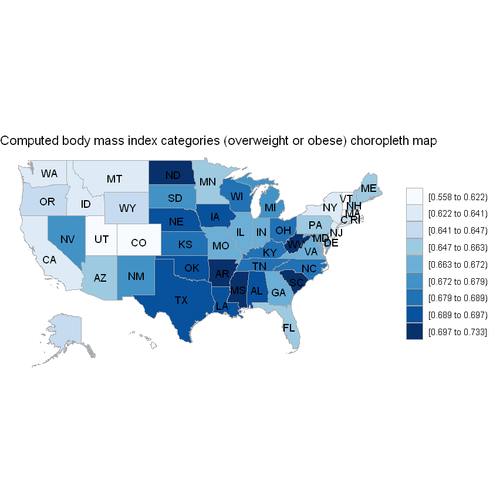

```r
state.bmi2 <- state.bmi %>%
  filter(X_BMI5CAT2==1) %>%
  select(region=state.name, value=prevalence)
choroplethr::state_choropleth(state.bmi2, title="Computed body mass index categories (overweight or obese) choropleth map", num_colors=9)
```

```r
state.ht <- brfss.design %>%
  group_by(X_STATE, GENHLTH2) %>%
  summarize(prevalence = survey_mean(na.rm=T, vartype = c("ci")),
            N = survey_total(na.rm=T)) %>%
  mutate(X_STATE = as.character(X_STATE))
```

```r
state.ht[1:5,]
```

| X_STATE | GENHLTH2 | prevalence | prevalence_low | prevalence_upp | N | N_se |
| --- | --- | --- | --- | --- | --- | --- |
| 1 | 0 | 0.765532354 | 0.751932898 | 0.779131809 | 2916875.77 | 40775.014 |
| 1 | 1 | 0.227773312 | 0.214365631 | 0.241180994 | 867875.08 | 26890.580 |
| 1 | (Missing) | 0.006694334 | 0.003711165 | 0.009677503 | 25507.14 | 5814.350 |
| 2 | 0 | 0.840453061 | 0.820503971 | 0.860402150 | 467618.84 | 8662.001 |
| 2 | 1 | 0.155218420 | 0.135483258 | 0.174953582 | 86361.82 | 5748.416 |

```r
state.ht <- state.ht %>%
  mutate(X_STATE = str_pad(X_STATE, 2, side="left", pad="0")) %>%
  left_join(county.regions, by=c("X_STATE"="state.fips.character")) %>%
  mutate(state.name = ifelse(X_STATE=="72", "puerto rico",
                             ifelse(X_STATE=="66", "guam", state.name)))
```

```r
state.ht[1:5,]
```

| X_STATE | GENHLTH2 | prevalence | prevalence_low | prevalence_upp | N | N_se | state.name |
| --- | --- | --- | --- | --- | --- | --- | --- |
| 01 | 0 | 0.765532354 | 0.751932898 | 0.779131809 | 2916875.77 | 40775.014 | alabama |
| 01 | 1 | 0.227773312 | 0.214365631 | 0.241180994 | 867875.08 | 26890.580 | alabama |
| 01 | (Missing) | 0.006694334 | 0.003711165 | 0.009677503 | 25507.14 | 5814.350 | alabama |
| 02 | 0 | 0.840453061 | 0.820503971 | 0.860402150 | 467618.84 | 8662.001 | alaska |
| 02 | 1 | 0.155218420 | 0.135483258 | 0.174953582 | 86361.82 | 5748.416 | alaska |

[figure not shown]

```r
state.ht %>% filter(GENHLTH2==1) %>%
    ggplot(aes(y=reorder(state.name, prevalence), x=prevalence, xmin=prevalence_low, xmax=prevalence_upp)) +
    geom_point() +
    geom_errorbarh(height=0) +
    labs(y="State", x=NULL,
       title="Health Condition Fair or Poor by State",
       caption="2014 CDC BRFSS") +
    theme_bw() +
    theme(axis.text.y=element_text(size=rel(0.8)))
```

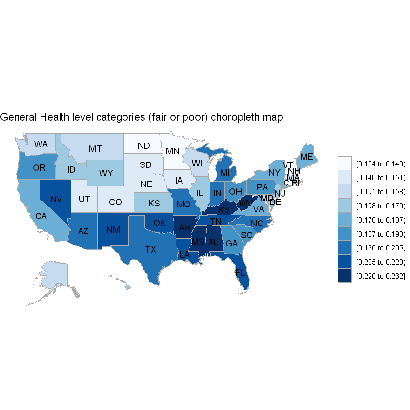

```r
state.ht2 <- state.ht %>%
  filter(GENHLTH2==1) %>%
  select(region=state.name, value=prevalence)
choroplethr::state_choropleth(state.ht2, title="General Health level categories (fair or poor) choropleth map", num_colors=9)
```

## Research Question 2

So far, we used survey design, and observational weights, `X_LLCPWT`, are used for the analysis. However, many times we may not need such weight modifications. This time, let's assume each sample in the survey have the same importance. and look at research question :

> How is the prevalance of Overweight/Obesity and General Health level (fair or poor) with respect to Educational level or annual income in Wisconsin State?

Take Wisconsin state(55) from data

```r
brfss18 <- brfss18 %>% tbl_df()

brfss_wisc <- brfss18 %>% filter(X_STATE == 55)
```

Do some preprocessing:

```r
brfss_wisc <- brfss_wisc %>%
  mutate(
    X_EDUCAG2   = car::recode(X_EDUCAG, "1='<High School'; 2='Graduated High School'; 3='Attended College or Technical School'; 4='Graduated College or Technical School'; else=NA"),
    X_EDUCAG2   = factor(X_EDUCAG2, levels = c('<High School', 'Graduated High School', 'Attended College or Technical School', 'Graduated College or Technical School')),
    X_EDUCAG2   = fct_explicit_na(X_EDUCAG2),
    X_BMI5CAT2  = car::recode(X_BMI5CAT, "c(3,4)=1; NA=NA;  else=0"),
    X_BMI5CAT2  = as.factor(X_BMI5CAT2),
    X_BMI5CAT2a = car::recode(X_BMI5CAT2, "1='Obese/overweight'; NA=NA; else='Not Obese/overweight'"),
    X_BMI5CAT2a = factor(X_BMI5CAT2a, levels=c('Obese/overweight', 'Not Obese/overweight'), ordered=TRUE),
    X_BMI5CAT2 = fct_explicit_na(X_BMI5CAT2),
    X_BMI5CAT2a = fct_explicit_na(X_BMI5CAT2a),
    INCOME2a   = car::recode(INCOME2, "1='<10,000'; 2='10,000~15,000'; 3='15,000~20,000'; 4='20,000~25,000'; 5='25,000~35,000'; 6='35,000~50,000'; 7='50,000~75,000'; 8='>75,000';  NA=NA; else=NA"),
    INCOME2a   = factor(INCOME2a, levels = c('<10,000', '10,000~15,000', '15,000~20,000', '20,000~25,000', '25,000~35,000', '35,000~50,000', '50,000~75,000', '>75,000')),
    INCOME2a = fct_explicit_na(INCOME2a),
    GENHLTH2  = car::recode(GENHLTH, "c(4,5)=1; c(1,2,3) = 0; NA=NA; else = NA"),
    GENHLTH2  = as.factor(GENHLTH2),
    GENHLTH2a = car::recode(GENHLTH2, "1='Fair/Poor'; NA=NA; else='G/VG/Excelent'"),
    GENHLTH2a = factor(GENHLTH2a, levels=c('Fair/Poor', 'G/VG/Excelent'), ordered=TRUE),
    GENHLTH2 = fct_explicit_na(GENHLTH2),
    GENHLTH2a = fct_explicit_na(GENHLTH2a),
    SEX1   = car::recode(SEX1, "1='MALE'; 2='FEMALE'; else=NA"),
    SEX1   = factor(SEX1, levels = c('MALE', 'FEMALE') )  ,
    SEX1 = fct_explicit_na(SEX1)
  )
```

Prevalence of Overweight/Obesity, General Health with respect to educational level

```r
tb_wisc <- brfss_wisc  %>%
    select(X_EDUCAG2, X_BMI5CAT2a, INCOME2a, GENHLTH2a, SEX1, X_BMI5CAT) %>%
    group_by(X_EDUCAG2) %>%
    summarize(prevalence_highBMI = sum(as.numeric(X_BMI5CAT2a) == 1) / sum(as.numeric(X_BMI5CAT2a) %in% 1:2),
              prevalence_GENHLTH2a = sum(GENHLTH2a == 'Fair/Poor') / sum(!(GENHLTH2a %in% '(Missing)')),
              prevalance_overweight = sum(X_BMI5CAT == 3, na.rm=T) / sum(X_BMI5CAT %in% 1:4, na.rm=T),
              prevalance_obesity = sum(X_BMI5CAT == 4, na.rm=T) / sum(X_BMI5CAT %in% 1:4, na.rm=T),
            N = n())

tb_wisc
```

| X_EDUCAG2 | prevalence_highBMI | prevalence_GENHLTH2a | prevalance_overweight | prevalance_obesity | N |
| --- | --- | --- | --- | --- | --- |
| <High School | 0.7098214 | 0.3654618 | 0.3392857 | 0.3705357 | 249 |
| Graduated High School | 0.7341772 | 0.2155340 | 0.3684951 | 0.3656821 | 1547 |
| Attended College or Technical School | 0.7334361 | 0.1704225 | 0.3559322 | 0.3775039 | 1424 |
| Graduated College or Technical School | 0.6483180 | 0.1000569 | 0.3681957 | 0.2801223 | 1759 |
| (Missing) | 0.5000000 | 0.1764706 | 0.3333333 | 0.1666667 | 17 |

### Prevalence of General Health level(fair/poor) w.r.t Education level

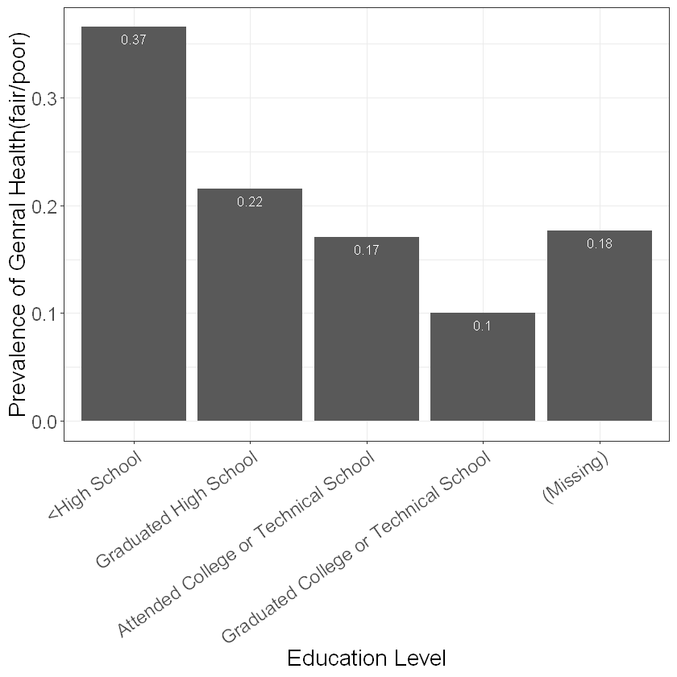

```r
tb_wisc %>%
ggplot( aes(y = prevalence_GENHLTH2a, x = X_EDUCAG2) ) +
    geom_bar(stat="identity") +
    geom_text(aes(label=round(prevalence_GENHLTH2a,2)), vjust=1.6, color="white", size=3.5)+
    xlab('Education Level') +
    ylab('Prevalence of Genral Health(fair/poor)') +
    theme_bw() +
#    theme_minimal() +
    theme(
        text = element_text(size = 17),
        axis.text.x = element_text(angle=35, hjust = 1)
    )
```

### Relationship between Income and Educational level

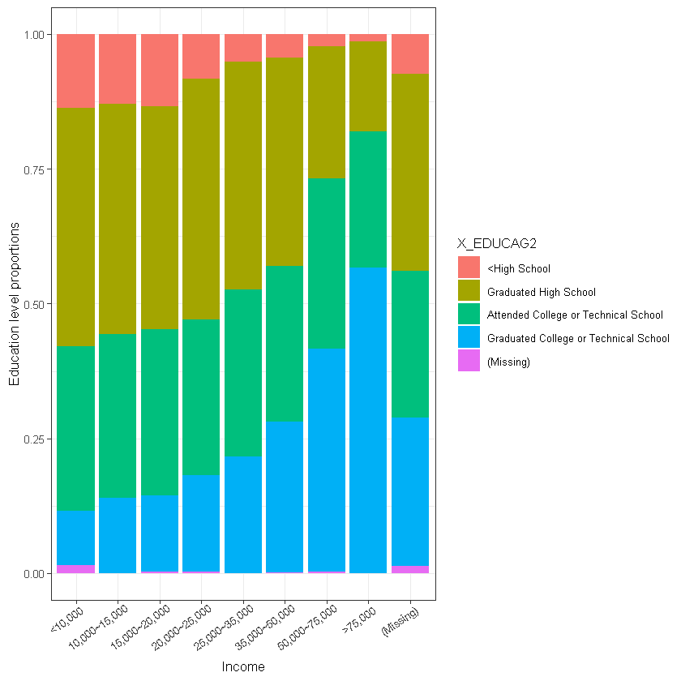

```r
brfss_wisc  %>%
    select(INCOME2a, X_EDUCAG2) %>%
    group_by(INCOME2a, X_EDUCAG2) %>%
    tally() %>%
    group_by(INCOME2a) %>%
    mutate(edu_ratio = n / sum(n)) %>% ggplot() +
    geom_col(aes( x = INCOME2a, y = edu_ratio, fill = X_EDUCAG2),
             position = "stack") +
    xlab('Income') +
    ylab('Education level proportions') +
    theme_bw() +
#    theme_minimal() +
    theme(
        text = element_text(size = 10),
        axis.text.x = element_text(angle=35, hjust = .9)
    )
```

### Prevalence of General Health (Fair/Poor) w.r.t Annual Income

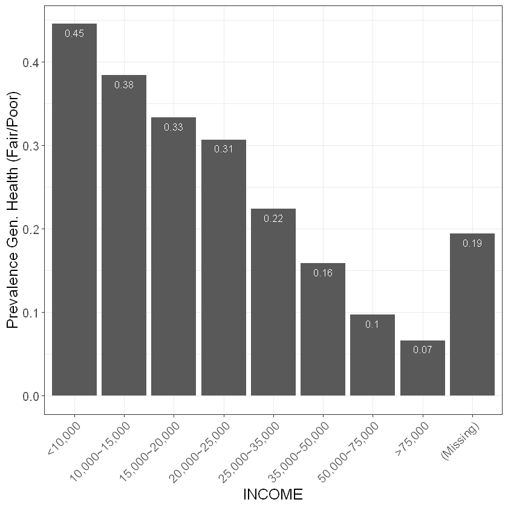

```r
brfss_wisc  %>%
    select(X_EDUCAG2, X_BMI5CAT2a, INCOME2a, GENHLTH2a, SEX1, X_BMI5CAT) %>%
    group_by(INCOME2a) %>%
    summarize(prevalence_highBMI = sum(as.numeric(X_BMI5CAT2a) == 1) / sum(as.numeric(X_BMI5CAT2a) %in% 1:2),
              prevalence_GENHLTH2a = sum(GENHLTH2a == 'Fair/Poor') / sum(!(GENHLTH2a %in% '(Missing)')),
              prevalance_overweight = sum(X_BMI5CAT == 3, na.rm=T) / sum(X_BMI5CAT %in% 1:4, na.rm=T),
              prevalance_obesity = sum(X_BMI5CAT == 4, na.rm=T) / sum(X_BMI5CAT %in% 1:4, na.rm=T),
            N = n()) %>%
    ggplot( aes(y = prevalence_GENHLTH2a, x = INCOME2a) ) +
    geom_bar(stat="identity") +
    geom_text(aes(label=round(prevalence_GENHLTH2a,2)), vjust=1.6, color="white", size=3.5)+
    xlab('INCOME') +
    ylab('Prevalence Gen. Health (Fair/Poor)') +
    theme_bw() +
#    theme_minimal() +
    theme(
        text = element_text(size = 15),
        axis.text.x = element_text(angle=45, hjust = 1)
    )
```

### Distribution of Annual Income for residents in WI

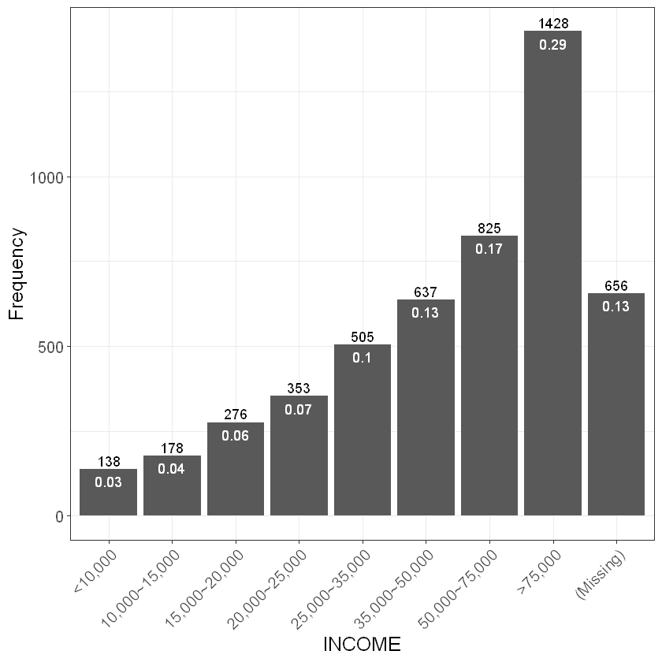

```r
brfss_wisc  %>%
    select(INCOME2a) %>%
    group_by(INCOME2a) %>%
    summarize(n = n()) %>%
    ggplot( aes(y = n, x = INCOME2a) ) +
    geom_bar(stat="identity") +
    geom_text(aes(label=round(n/sum(n),2)), vjust=1.6, color = "white") +
    geom_text(aes(label=n), vjust=-.3) +
    xlab('INCOME') +
    ylab('Frequency') +
    theme_bw() +
#    theme_minimal() +
    theme(
        text = element_text(size = 15),
        axis.text.x = element_text(angle=45, hjust = 1)
    )
```